# Int_Preprocessing_LR-Draft-v1.4

## Предобработка данных и логистическая регрессия для задачи бинарной классификации

## Programming assignment

предобработка данных и обучение модели логистической регрессии

```python
import pandas as pd
import numpy as np
import matplotlib
from matplotlib import pyplot as plt
matplotlib.style.use('ggplot')
%matplotlib inline
```

## Описание датасета

Задача: по 38 признакам, связанных с заявкой на грант (область исследований учёных, информация по их академическому бэкграунду, размер гранта, область, в которой он выдаётся) предсказать, будет ли заявка принята. Датасет включает в себя информацию по 6000 заявкам на гранты, которые были поданы в университете Мельбурна в период с 2004 по 2008 год.

Полную версию данных с большим количеством признаков можно найти на https://www.kaggle.com/c/unimelb.

```python
data = pd.read_csv('data.csv')
data.shape
```

```
(6000, 39)
```

Выделим из датасета целевую переменную Grant.Status и обозначим её за y Теперь X обозначает обучающую выборку, y - ответы на ней

```python
X = data.drop('Grant.Status', 1)
y = data['Grant.Status']
```

## Предобработка данных

Из свойств данной модели следует, что:

- все $X$ должны быть числовыми данными
- среди $X$ не должно быть пропущенных значений

```python
data.head(100)
```

|  | Grant.Status | Sponsor.Code | Grant.Category.Code | Contract.Value.Band...see.note.A | RFCD.Code.1 | RFCD.Percentage.1 | RFCD.Code.2 | RFCD.Percentage.2 | RFCD.Code.3 | RFCD.Percentage.3 | ... | Dept.No..1 | Faculty.No..1 | With.PHD.1 | No..of.Years.in.Uni.at.Time.of.Grant.1 | Number.of.Successful.Grant.1 | Number.of.Unsuccessful.Grant.1 | A..1 | A.1 | B.1 | C.1 |
| --- | --- | --- | --- | --- | --- | --- | --- | --- | --- | --- | --- | --- | --- | --- | --- | --- | --- | --- | --- | --- | --- |
| 0 | 1 | 21A | 50A | A | 230202.0 | 50.0 | 230203.0 | 30.0 | 230204.0 | 20.0 | ... | 3098.0 | 31.0 | Yes | >=0 to 5 | 2.0 | 0.0 | 0.0 | 4.0 | 2.0 | 0.0 |
| 1 | 1 | 4D | 10A | D | 320801.0 | 100.0 | 0.0 | 0.0 | 0.0 | 0.0 | ... | 2553.0 | 25.0 | Yes | >=0 to 5 | 3.0 | 1.0 | 0.0 | 2.0 | 0.0 | 0.0 |
| 2 | 0 | NaN | NaN | NaN | 320602.0 | 50.0 | 321004.0 | 30.0 | 321015.0 | 20.0 | ... | 2813.0 | 25.0 | NaN | Less than 0 | 1.0 | 5.0 | 0.0 | 7.0 | 2.0 | 0.0 |
| 3 | 0 | 51C | 20C | A | 291503.0 | 60.0 | 321402.0 | 40.0 | 0.0 | 0.0 | ... | 2553.0 | 25.0 | NaN | more than 15 | 2.0 | 1.0 | 5.0 | 6.0 | 9.0 | 1.0 |
| 4 | 0 | 24D | 30B | NaN | 380107.0 | 100.0 | 0.0 | 0.0 | 0.0 | 0.0 | ... | 2923.0 | 25.0 | NaN | Less than 0 | 0.0 | 2.0 | 0.0 | 0.0 | 0.0 | 0.0 |
| 5 | 1 | 288D | 30B | A | 321105.0 | 100.0 | 0.0 | 0.0 | 0.0 | 0.0 | ... | 2568.0 | 25.0 | Yes | >=0 to 5 | 0.0 | 4.0 | 0.0 | 1.0 | 0.0 | 2.0 |
| 6 | 1 | 21A | 50A | A | 380205.0 | 40.0 | 379902.0 | 30.0 | 380102.0 | 30.0 | ... | 593.0 | 7.0 | Yes | >5 to 10 | 1.0 | 0.0 | 1.0 | 2.0 | 6.0 | 0.0 |
| 7 | 1 | 2B | 10A | D | 410302.0 | 40.0 | 420306.0 | 30.0 | 379999.0 | 30.0 | ... | 528.0 | 7.0 | Yes | more than 15 | 0.0 | 1.0 | 0.0 | 2.0 | 3.0 | 2.0 |
| 8 | 1 | 34B | 30C | A | 270401.0 | 100.0 | 0.0 | 0.0 | 0.0 | 0.0 | ... | NaN | NaN | NaN | NaN | NaN | NaN | NaN | NaN | NaN | NaN |
| 9 | 1 | NaN | NaN | C | 270802.0 | 100.0 | 0.0 | 0.0 | 0.0 | 0.0 | ... | 2578.0 | 25.0 | Yes | more than 15 | 3.0 | 1.0 | 7.0 | 21.0 | 31.0 | 15.0 |
| 10 | 1 | 40D | 30B | A | 320502.0 | 100.0 | 0.0 | 0.0 | 0.0 | 0.0 | ... | 2668.0 | 25.0 | NaN | NaN | 1.0 | 0.0 | 0.0 | 0.0 | 0.0 | 0.0 |
| 11 | 1 | NaN | NaN | NaN | 330109.0 | 100.0 | 0.0 | 0.0 | 0.0 | 0.0 | ... | 2298.0 | 46.0 | NaN | Less than 0 | 0.0 | 0.0 | 0.0 | 0.0 | 2.0 | 1.0 |
| 12 | 0 | 34B | 30C | B | 380107.0 | 100.0 | 0.0 | 0.0 | 0.0 | 0.0 | ... | 2768.0 | 25.0 | Yes | >=0 to 5 | 4.0 | 4.0 | 0.0 | 0.0 | 0.0 | 1.0 |
| 13 | 1 | 4D | 10A | F | 321202.0 | 100.0 | 0.0 | 0.0 | 0.0 | 0.0 | ... | 2523.0 | 25.0 | NaN | Less than 0 | 0.0 | 5.0 | 14.0 | 7.0 | 4.0 | 4.0 |
| 14 | 0 | 210B | 30B | NaN | 350107.0 | 100.0 | 0.0 | 0.0 | 0.0 | 0.0 | ... | 1528.0 | 13.0 | NaN | Less than 0 | 0.0 | 1.0 | 0.0 | 1.0 | 17.0 | 12.0 |
| 15 | 0 | 24D | 30B | NaN | 320702.0 | 80.0 | 321005.0 | 10.0 | 321204.0 | 10.0 | ... | 2578.0 | 25.0 | NaN | Less than 0 | 0.0 | 2.0 | 4.0 | 10.0 | 4.0 | 6.0 |
| 16 | 1 | 5A | 30B | A | 419901.0 | 100.0 | 0.0 | 0.0 | 0.0 | 0.0 | ... | 528.0 | 7.0 | Yes | >5 to 10 | 2.0 | 3.0 | 2.0 | 4.0 | 1.0 | 0.0 |
| 17 | 0 | 97A | 30B | B | 380103.0 | 20.0 | 380107.0 | 80.0 | 0.0 | 0.0 | ... | 2558.0 | 25.0 | Yes | >10 to 15 | 0.0 | 3.0 | 2.0 | 7.0 | 14.0 | 1.0 |
| 18 | 0 | 183C | 10A | D | 370302.0 | 100.0 | 0.0 | 0.0 | 0.0 | 0.0 | ... | 803.0 | 7.0 | NaN | Less than 0 | 0.0 | 3.0 | 0.0 | 4.0 | 6.0 | 2.0 |
| 19 | 0 | 32D | 30B | NaN | 321015.0 | 100.0 | 0.0 | 0.0 | 0.0 | 0.0 | ... | 2813.0 | 25.0 | NaN | >=0 to 5 | 0.0 | 1.0 | 0.0 | 0.0 | 0.0 | 0.0 |
| 20 | 1 | 34B | 30C | A | 270702.0 | 50.0 | 270706.0 | 50.0 | 0.0 | 0.0 | ... | 3268.0 | 31.0 | Yes | more than 15 | 2.0 | 0.0 | 0.0 | 3.0 | 5.0 | 4.0 |
| 21 | 0 | 4D | 10A | G | 321015.0 | 100.0 | 0.0 | 0.0 | 0.0 | 0.0 | ... | 2653.0 | 25.0 | NaN | >5 to 10 | 1.0 | 14.0 | 5.0 | 6.0 | 2.0 | 0.0 |
| 22 | 1 | 4D | 10A | NaN | 210000.0 | 50.0 | 320206.0 | 50.0 | 0.0 | 0.0 | ... | NaN | NaN | NaN | NaN | NaN | NaN | NaN | NaN | NaN | NaN |
| 23 | 0 | 133A | 30D | NaN | 360105.0 | 70.0 | 360199.0 | 30.0 | 0.0 | 0.0 | ... | 828.0 | 7.0 | Yes | more than 15 | 0.0 | 1.0 | 0.0 | 4.0 | 8.0 | 0.0 |
| 24 | 1 | 77A | 30B | A | 321024.0 | 100.0 | 0.0 | 0.0 | 0.0 | 0.0 | ... | 2563.0 | 25.0 | Yes | >=0 to 5 | 1.0 | 2.0 | 7.0 | 4.0 | 3.0 | 1.0 |
| 25 | 1 | NaN | NaN | B | 309999.0 | 80.0 | 321012.0 | 10.0 | 329903.0 | 10.0 | ... | 1258.0 | 34.0 | NaN | Less than 0 | 0.0 | 0.0 | 0.0 | 0.0 | 9.0 | 1.0 |
| 26 | 1 | 163C | 10A | A | 430111.0 | 50.0 | 430101.0 | 50.0 | 0.0 | 0.0 | ... | 603.0 | 7.0 | NaN | NaN | 1.0 | 0.0 | 0.0 | 0.0 | 0.0 | 0.0 |
| 27 | 0 | 33A | 20C | G | 300105.0 | 70.0 | 300302.0 | 10.0 | 300305.0 | 10.0 | ... | 998.0 | 1.0 | Yes | NaN | 0.0 | 4.0 | 0.0 | 1.0 | 3.0 | 0.0 |
| 28 | 0 | 42B | 20A | NaN | NaN | NaN | NaN | NaN | NaN | NaN | ... | 2568.0 | 25.0 | NaN | NaN | 0.0 | 2.0 | 4.0 | 14.0 | 10.0 | 5.0 |
| 29 | 0 | 4D | 10A | NaN | 270103.0 | 50.0 | 270105.0 | 50.0 | 0.0 | 0.0 | ... | 2653.0 | 25.0 | NaN | >5 to 10 | 1.0 | 1.0 | 5.0 | 1.0 | 0.0 | 1.0 |
| ... | ... | ... | ... | ... | ... | ... | ... | ... | ... | ... | ... | ... | ... | ... | ... | ... | ... | ... | ... | ... | ... |
| 70 | 1 | 59C | 20C | K | 239901.0 | 100.0 | 0.0 | 0.0 | 0.0 | 0.0 | ... | 2763.0 | 25.0 | Yes | >=0 to 5 | 2.0 | 1.0 | 1.0 | 11.0 | 4.0 | 5.0 |
| 71 | 1 | 21A | 50A | A | 321004.0 | 40.0 | 321003.0 | 30.0 | 321207.0 | 30.0 | ... | 2813.0 | 25.0 | NaN | >5 to 10 | 5.0 | 11.0 | 16.0 | 17.0 | 23.0 | 4.0 |
| 72 | 0 | 4D | 10A | C | 320705.0 | 30.0 | 321024.0 | 40.0 | 321013.0 | 30.0 | ... | NaN | NaN | NaN | NaN | 0.0 | 0.0 | 3.0 | 0.0 | 1.0 | 0.0 |
| 73 | 1 | NaN | NaN | A | 300507.0 | 40.0 | 300401.0 | 20.0 | 300405.0 | 20.0 | ... | 1258.0 | 34.0 | Yes | >=0 to 5 | 0.0 | 2.0 | 0.0 | 2.0 | 0.0 | 0.0 |
| 74 | 0 | 221A | 30B | B | 270603.0 | 60.0 | 321003.0 | 30.0 | 320603.0 | 10.0 | ... | 2678.0 | 25.0 | Yes | >5 to 10 | 5.0 | 14.0 | 0.0 | 9.0 | 7.0 | 0.0 |
| 75 | 0 | 59C | 20C | D | 270201.0 | 100.0 | 0.0 | 0.0 | 0.0 | 0.0 | ... | 2553.0 | 25.0 | NaN | Less than 0 | 1.0 | 1.0 | 0.0 | 3.0 | 3.0 | 1.0 |
| 76 | 0 | 2B | 10A | NaN | 350212.0 | 100.0 | 0.0 | 0.0 | 0.0 | 0.0 | ... | NaN | NaN | NaN | NaN | NaN | NaN | NaN | NaN | NaN | NaN |
| 77 | 1 | 4D | 10A | F | 320502.0 | 100.0 | 0.0 | 0.0 | 0.0 | 0.0 | ... | 2668.0 | 25.0 | NaN | Less than 0 | 2.0 | 0.0 | 10.0 | 7.0 | 4.0 | 0.0 |
| 78 | 0 | 266B | 10A | NaN | 270299.0 | 100.0 | 0.0 | 0.0 | 0.0 | 0.0 | ... | 2653.0 | 25.0 | Yes | >5 to 10 | 4.0 | 16.0 | 14.0 | 49.0 | 19.0 | 5.0 |
| 79 | 1 | 4D | 10A | C | 321030.0 | 100.0 | 0.0 | 0.0 | 0.0 | 0.0 | ... | 2893.0 | 25.0 | NaN | >5 to 10 | 1.0 | 4.0 | 0.0 | 16.0 | 21.0 | 9.0 |
| 80 | 1 | 4D | 20C | A | 321015.0 | 100.0 | 0.0 | 0.0 | 0.0 | 0.0 | ... | 2778.0 | 25.0 | Yes | >5 to 10 | 0.0 | 0.0 | 2.0 | 3.0 | 37.0 | 32.0 |
| 81 | 1 | 34B | 30C | A | 270603.0 | 40.0 | 321005.0 | 40.0 | 321014.0 | 20.0 | ... | 3268.0 | 31.0 | Yes | >10 to 15 | 4.0 | 3.0 | 4.0 | 12.0 | 5.0 | 1.0 |
| 82 | 0 | 2B | 10A | NaN | 390106.0 | 40.0 | 390402.0 | 40.0 | 390102.0 | 20.0 | ... | NaN | NaN | NaN | NaN | 0.0 | 0.0 | 0.0 | 1.0 | 6.0 | 2.0 |
| 83 | 1 | NaN | NaN | B | 280210.0 | 100.0 | 0.0 | 0.0 | 0.0 | 0.0 | ... | NaN | NaN | NaN | NaN | 0.0 | 0.0 | 0.0 | 0.0 | 0.0 | 0.0 |
| 84 | 0 | 149A | 30B | C | 321204.0 | 60.0 | 321216.0 | 20.0 | 321299.0 | 20.0 | ... | 2523.0 | 25.0 | Yes | >10 to 15 | 4.0 | 5.0 | 2.0 | 2.0 | 2.0 | 7.0 |
| 85 | 1 | 21A | 50A | A | 321012.0 | 50.0 | 321004.0 | 50.0 | 0.0 | 0.0 | ... | 2813.0 | 25.0 | Yes | >5 to 10 | 6.0 | 10.0 | 19.0 | 34.0 | 9.0 | 10.0 |
| 86 | 0 | 4D | 10A | NaN | 321202.0 | 100.0 | 0.0 | 0.0 | 0.0 | 0.0 | ... | 2523.0 | 25.0 | Yes | >=0 to 5 | 0.0 | 1.0 | 6.0 | 8.0 | 2.0 | 0.0 |
| 87 | 0 | 2B | 10A | NaN | 420399.0 | 40.0 | 420307.0 | 30.0 | 400104.0 | 30.0 | ... | NaN | NaN | NaN | NaN | NaN | NaN | NaN | NaN | NaN | NaN |
| 88 | 1 | NaN | NaN | NaN | NaN | NaN | NaN | NaN | NaN | NaN | ... | 3048.0 | 31.0 | Yes | more than 15 | 1.0 | 0.0 | 11.0 | 3.0 | 10.0 | 1.0 |
| 89 | 1 | 40D | 10B | D | 270603.0 | 100.0 | 0.0 | 0.0 | 0.0 | 0.0 | ... | 2603.0 | 25.0 | NaN | >=0 to 5 | 2.0 | 0.0 | 9.0 | 6.0 | 7.0 | 0.0 |
| 90 | 1 | 40D | 30B | A | 321003.0 | 40.0 | 320602.0 | 35.0 | 321004.0 | 25.0 | ... | 2678.0 | 25.0 | Yes | >10 to 15 | 5.0 | 0.0 | 1.0 | 3.0 | 14.0 | 3.0 |
| 91 | 0 | 2B | 10A | NaN | 330202.0 | 40.0 | 330303.0 | 30.0 | 330302.0 | 30.0 | ... | 3098.0 | 31.0 | Yes | more than 15 | 0.0 | 0.0 | 4.0 | 10.0 | 9.0 | 1.0 |
| 92 | 0 | 4D | 10A | NaN | 321015.0 | 100.0 | 0.0 | 0.0 | 0.0 | 0.0 | ... | 2523.0 | 25.0 | NaN | Less than 0 | 0.0 | 5.0 | 9.0 | 6.0 | 2.0 | 4.0 |
| 93 | 1 | 208D | 30B | A | 321010.0 | 100.0 | 0.0 | 0.0 | 0.0 | 0.0 | ... | 2548.0 | 25.0 | Yes | >=0 to 5 | 3.0 | 4.0 | 1.0 | 0.0 | 4.0 | 1.0 |
| 94 | 0 | 2B | 10A | NaN | 240201.0 | 40.0 | 230202.0 | 30.0 | 230107.0 | 30.0 | ... | 2178.0 | 19.0 | NaN | >5 to 10 | 0.0 | 1.0 | 0.0 | 0.0 | 0.0 | 0.0 |
| 95 | 1 | 149A | 30B | B | 321208.0 | 60.0 | 321102.0 | 40.0 | 0.0 | 0.0 | ... | 2523.0 | 25.0 | Yes | >5 to 10 | 0.0 | 0.0 | 0.0 | 6.0 | 16.0 | 9.0 |
| 96 | 0 | 21A | 50A | A | NaN | NaN | NaN | NaN | NaN | NaN | ... | 1663.0 | 13.0 | NaN | NaN | 0.0 | 1.0 | 0.0 | 0.0 | 2.0 | 0.0 |
| 97 | 1 | 4D | 20C | A | 321003.0 | 80.0 | 321008.0 | 20.0 | 0.0 | 0.0 | ... | 2713.0 | 25.0 | NaN | >=0 to 5 | 0.0 | 1.0 | 0.0 | 2.0 | 3.0 | 0.0 |
| 98 | 1 | 34B | 30C | A | 270504.0 | 65.0 | 270799.0 | 35.0 | 0.0 | 0.0 | ... | 3268.0 | 31.0 | Yes | more than 15 | 2.0 | 2.0 | 7.0 | 24.0 | 34.0 | 7.0 |
| 99 | 0 | 62B | 10B | C | 321021.0 | 100.0 | 0.0 | 0.0 | 0.0 | 0.0 | ... | 2533.0 | 25.0 | Yes | >5 to 10 | 0.0 | 0.0 | 0.0 | 0.0 | 0.0 | 2.0 |

100 rows × 39 columns

списки названий:

```python
numeric_cols = ['RFCD.Percentage.1', 'RFCD.Percentage.2', 'RFCD.Percentage.3',
                'RFCD.Percentage.4', 'RFCD.Percentage.5',
                'SEO.Percentage.1', 'SEO.Percentage.2', 'SEO.Percentage.3',
                'SEO.Percentage.4', 'SEO.Percentage.5',
                'Year.of.Birth.1', 'Number.of.Successful.Grant.1', 'Number.of.Unsuccessful.Grant.1']
categorical_cols = list(set(X.columns.values.tolist()) - set(numeric_cols))
```

исключение всех данных, у которых пропущено хотя бы одно значение

```python
data.dropna().shape
```

```
(213, 39)
```

ушли почти все данные --> и такой метод решения в данном случае не сработает

Тогда:

Для вещественных признаков:

- заменить на 0
- заменить на среднее

Для категориальных:

- интерпретировать пропущенное значение, как ещё одну категорию

## Обработка пропущенных значений.

```python
data[numeric_cols].shape[0]
```

```
6000
```

```python
def calculate_means(numeric_data):
    means = np.zeros(numeric_data.shape[1])
    for j in range(numeric_data.shape[1]):
        to_sum = numeric_data.iloc[:,j]
        indices = np.nonzero(~numeric_data.iloc[:,j].isnull())[0]
        correction = np.amax(to_sum[indices])
        to_sum /= correction
        for i in indices:
            means[j] += to_sum[i]
        means[j] /= indices.size
        means[j] *= correction
    return pd.Series(means, numeric_data.columns)
```

примечание:

~ - инвентирует True и False

indices - это, соответственно, индексы всех непустых элементов

```python
# среднее
means = calculate_means(X[numeric_cols])
```

```python
means
```

```
RFCD.Percentage.1                   74.832348
RFCD.Percentage.2                   17.677593
RFCD.Percentage.3                    6.933011
RFCD.Percentage.4                    0.437937
RFCD.Percentage.5                    0.119112
SEO.Percentage.1                    71.483240
SEO.Percentage.2                    20.646880
SEO.Percentage.3                     6.926704
SEO.Percentage.4                     0.730804
SEO.Percentage.5                     0.212192
Year.of.Birth.1                   1962.449849
Number.of.Successful.Grant.1         1.177849
Number.of.Unsuccessful.Grant.1       2.097977
dtype: float64
```

```python
X_real_zeros = X.drop(categorical_cols, 1)
for mark in numeric_cols:
    ind_NaN = np.nonzero(X_real_zeros.loc[:, mark].isnull())[0]
    for i in ind_NaN:
        X_real_zeros.loc[i, (mark)] = 0
```

```python
X.head(29)
```

|  | Sponsor.Code | Grant.Category.Code | Contract.Value.Band...see.note.A | RFCD.Code.1 | RFCD.Percentage.1 | RFCD.Code.2 | RFCD.Percentage.2 | RFCD.Code.3 | RFCD.Percentage.3 | RFCD.Code.4 | ... | Dept.No..1 | Faculty.No..1 | With.PHD.1 | No..of.Years.in.Uni.at.Time.of.Grant.1 | Number.of.Successful.Grant.1 | Number.of.Unsuccessful.Grant.1 | A..1 | A.1 | B.1 | C.1 |
| --- | --- | --- | --- | --- | --- | --- | --- | --- | --- | --- | --- | --- | --- | --- | --- | --- | --- | --- | --- | --- | --- |
| 0 | 21A | 50A | A | 230202.0 | 50.0 | 230203.0 | 30.0 | 230204.0 | 20.0 | 0.0 | ... | 3098.0 | 31.0 | Yes | >=0 to 5 | 2.0 | 0.0 | 0.0 | 4.0 | 2.0 | 0.0 |
| 1 | 4D | 10A | D | 320801.0 | 100.0 | 0.0 | 0.0 | 0.0 | 0.0 | 0.0 | ... | 2553.0 | 25.0 | Yes | >=0 to 5 | 3.0 | 1.0 | 0.0 | 2.0 | 0.0 | 0.0 |
| 2 | NaN | NaN | NaN | 320602.0 | 50.0 | 321004.0 | 30.0 | 321015.0 | 20.0 | 0.0 | ... | 2813.0 | 25.0 | NaN | Less than 0 | 1.0 | 5.0 | 0.0 | 7.0 | 2.0 | 0.0 |
| 3 | 51C | 20C | A | 291503.0 | 60.0 | 321402.0 | 40.0 | 0.0 | 0.0 | 0.0 | ... | 2553.0 | 25.0 | NaN | more than 15 | 2.0 | 1.0 | 5.0 | 6.0 | 9.0 | 1.0 |
| 4 | 24D | 30B | NaN | 380107.0 | 100.0 | 0.0 | 0.0 | 0.0 | 0.0 | 0.0 | ... | 2923.0 | 25.0 | NaN | Less than 0 | 0.0 | 2.0 | 0.0 | 0.0 | 0.0 | 0.0 |
| 5 | 288D | 30B | A | 321105.0 | 100.0 | 0.0 | 0.0 | 0.0 | 0.0 | 0.0 | ... | 2568.0 | 25.0 | Yes | >=0 to 5 | 0.0 | 4.0 | 0.0 | 1.0 | 0.0 | 2.0 |
| 6 | 21A | 50A | A | 380205.0 | 40.0 | 379902.0 | 30.0 | 380102.0 | 30.0 | 0.0 | ... | 593.0 | 7.0 | Yes | >5 to 10 | 1.0 | 0.0 | 1.0 | 2.0 | 6.0 | 0.0 |
| 7 | 2B | 10A | D | 410302.0 | 40.0 | 420306.0 | 30.0 | 379999.0 | 30.0 | 0.0 | ... | 528.0 | 7.0 | Yes | more than 15 | 0.0 | 1.0 | 0.0 | 2.0 | 3.0 | 2.0 |
| 8 | 34B | 30C | A | 270401.0 | 100.0 | 0.0 | 0.0 | 0.0 | 0.0 | 0.0 | ... | NaN | NaN | NaN | NaN | NaN | NaN | NaN | NaN | NaN | NaN |
| 9 | NaN | NaN | C | 270802.0 | 100.0 | 0.0 | 0.0 | 0.0 | 0.0 | 0.0 | ... | 2578.0 | 25.0 | Yes | more than 15 | 3.0 | 1.0 | 7.0 | 21.0 | 31.0 | 15.0 |
| 10 | 40D | 30B | A | 320502.0 | 100.0 | 0.0 | 0.0 | 0.0 | 0.0 | 0.0 | ... | 2668.0 | 25.0 | NaN | NaN | 1.0 | 0.0 | 0.0 | 0.0 | 0.0 | 0.0 |
| 11 | NaN | NaN | NaN | 330109.0 | 100.0 | 0.0 | 0.0 | 0.0 | 0.0 | 0.0 | ... | 2298.0 | 46.0 | NaN | Less than 0 | 0.0 | 0.0 | 0.0 | 0.0 | 2.0 | 1.0 |
| 12 | 34B | 30C | B | 380107.0 | 100.0 | 0.0 | 0.0 | 0.0 | 0.0 | 0.0 | ... | 2768.0 | 25.0 | Yes | >=0 to 5 | 4.0 | 4.0 | 0.0 | 0.0 | 0.0 | 1.0 |
| 13 | 4D | 10A | F | 321202.0 | 100.0 | 0.0 | 0.0 | 0.0 | 0.0 | 0.0 | ... | 2523.0 | 25.0 | NaN | Less than 0 | 0.0 | 5.0 | 14.0 | 7.0 | 4.0 | 4.0 |
| 14 | 210B | 30B | NaN | 350107.0 | 100.0 | 0.0 | 0.0 | 0.0 | 0.0 | 0.0 | ... | 1528.0 | 13.0 | NaN | Less than 0 | 0.0 | 1.0 | 0.0 | 1.0 | 17.0 | 12.0 |
| 15 | 24D | 30B | NaN | 320702.0 | 80.0 | 321005.0 | 10.0 | 321204.0 | 10.0 | 0.0 | ... | 2578.0 | 25.0 | NaN | Less than 0 | 0.0 | 2.0 | 4.0 | 10.0 | 4.0 | 6.0 |
| 16 | 5A | 30B | A | 419901.0 | 100.0 | 0.0 | 0.0 | 0.0 | 0.0 | 0.0 | ... | 528.0 | 7.0 | Yes | >5 to 10 | 2.0 | 3.0 | 2.0 | 4.0 | 1.0 | 0.0 |
| 17 | 97A | 30B | B | 380103.0 | 20.0 | 380107.0 | 80.0 | 0.0 | 0.0 | 0.0 | ... | 2558.0 | 25.0 | Yes | >10 to 15 | 0.0 | 3.0 | 2.0 | 7.0 | 14.0 | 1.0 |
| 18 | 183C | 10A | D | 370302.0 | 100.0 | 0.0 | 0.0 | 0.0 | 0.0 | 0.0 | ... | 803.0 | 7.0 | NaN | Less than 0 | 0.0 | 3.0 | 0.0 | 4.0 | 6.0 | 2.0 |
| 19 | 32D | 30B | NaN | 321015.0 | 100.0 | 0.0 | 0.0 | 0.0 | 0.0 | 0.0 | ... | 2813.0 | 25.0 | NaN | >=0 to 5 | 0.0 | 1.0 | 0.0 | 0.0 | 0.0 | 0.0 |
| 20 | 34B | 30C | A | 270702.0 | 50.0 | 270706.0 | 50.0 | 0.0 | 0.0 | 0.0 | ... | 3268.0 | 31.0 | Yes | more than 15 | 2.0 | 0.0 | 0.0 | 3.0 | 5.0 | 4.0 |
| 21 | 4D | 10A | G | 321015.0 | 100.0 | 0.0 | 0.0 | 0.0 | 0.0 | 0.0 | ... | 2653.0 | 25.0 | NaN | >5 to 10 | 1.0 | 14.0 | 5.0 | 6.0 | 2.0 | 0.0 |
| 22 | 4D | 10A | NaN | 210000.0 | 50.0 | 320206.0 | 50.0 | 0.0 | 0.0 | 0.0 | ... | NaN | NaN | NaN | NaN | NaN | NaN | NaN | NaN | NaN | NaN |
| 23 | 133A | 30D | NaN | 360105.0 | 70.0 | 360199.0 | 30.0 | 0.0 | 0.0 | 0.0 | ... | 828.0 | 7.0 | Yes | more than 15 | 0.0 | 1.0 | 0.0 | 4.0 | 8.0 | 0.0 |
| 24 | 77A | 30B | A | 321024.0 | 100.0 | 0.0 | 0.0 | 0.0 | 0.0 | 0.0 | ... | 2563.0 | 25.0 | Yes | >=0 to 5 | 1.0 | 2.0 | 7.0 | 4.0 | 3.0 | 1.0 |
| 25 | NaN | NaN | B | 309999.0 | 80.0 | 321012.0 | 10.0 | 329903.0 | 10.0 | 0.0 | ... | 1258.0 | 34.0 | NaN | Less than 0 | 0.0 | 0.0 | 0.0 | 0.0 | 9.0 | 1.0 |
| 26 | 163C | 10A | A | 430111.0 | 50.0 | 430101.0 | 50.0 | 0.0 | 0.0 | 0.0 | ... | 603.0 | 7.0 | NaN | NaN | 1.0 | 0.0 | 0.0 | 0.0 | 0.0 | 0.0 |
| 27 | 33A | 20C | G | 300105.0 | 70.0 | 300302.0 | 10.0 | 300305.0 | 10.0 | 300201.0 | ... | 998.0 | 1.0 | Yes | NaN | 0.0 | 4.0 | 0.0 | 1.0 | 3.0 | 0.0 |
| 28 | 42B | 20A | NaN | NaN | NaN | NaN | NaN | NaN | NaN | NaN | ... | 2568.0 | 25.0 | NaN | NaN | 0.0 | 2.0 | 4.0 | 14.0 | 10.0 | 5.0 |

29 rows × 38 columns

```python
X_real_zeros.head(29)
```

|  | RFCD.Percentage.1 | RFCD.Percentage.2 | RFCD.Percentage.3 | RFCD.Percentage.4 | RFCD.Percentage.5 | SEO.Percentage.1 | SEO.Percentage.2 | SEO.Percentage.3 | SEO.Percentage.4 | SEO.Percentage.5 | Year.of.Birth.1 | Number.of.Successful.Grant.1 | Number.of.Unsuccessful.Grant.1 |
| --- | --- | --- | --- | --- | --- | --- | --- | --- | --- | --- | --- | --- | --- |
| 0 | 50.0 | 30.0 | 20.0 | 0.0 | 0.0 | 100.0 | 0.0 | 0.0 | 0.0 | 0.0 | 1965.0 | 2.0 | 0.0 |
| 1 | 100.0 | 0.0 | 0.0 | 0.0 | 0.0 | 100.0 | 0.0 | 0.0 | 0.0 | 0.0 | 1965.0 | 3.0 | 1.0 |
| 2 | 50.0 | 30.0 | 20.0 | 0.0 | 0.0 | 60.0 | 20.0 | 20.0 | 0.0 | 0.0 | 1955.0 | 1.0 | 5.0 |
| 3 | 60.0 | 40.0 | 0.0 | 0.0 | 0.0 | 60.0 | 40.0 | 0.0 | 0.0 | 0.0 | 1950.0 | 2.0 | 1.0 |
| 4 | 100.0 | 0.0 | 0.0 | 0.0 | 0.0 | 50.0 | 50.0 | 0.0 | 0.0 | 0.0 | 1970.0 | 0.0 | 2.0 |
| 5 | 100.0 | 0.0 | 0.0 | 0.0 | 0.0 | 50.0 | 50.0 | 0.0 | 0.0 | 0.0 | 1960.0 | 0.0 | 4.0 |
| 6 | 40.0 | 30.0 | 30.0 | 0.0 | 0.0 | 40.0 | 30.0 | 30.0 | 0.0 | 0.0 | 1950.0 | 1.0 | 0.0 |
| 7 | 40.0 | 30.0 | 30.0 | 0.0 | 0.0 | 40.0 | 30.0 | 30.0 | 0.0 | 0.0 | 1955.0 | 0.0 | 1.0 |
| 8 | 100.0 | 0.0 | 0.0 | 0.0 | 0.0 | 100.0 | 0.0 | 0.0 | 0.0 | 0.0 | 0.0 | 0.0 | 0.0 |
| 9 | 100.0 | 0.0 | 0.0 | 0.0 | 0.0 | 100.0 | 0.0 | 0.0 | 0.0 | 0.0 | 1945.0 | 3.0 | 1.0 |
| 10 | 100.0 | 0.0 | 0.0 | 0.0 | 0.0 | 100.0 | 0.0 | 0.0 | 0.0 | 0.0 | 1980.0 | 1.0 | 0.0 |
| 11 | 100.0 | 0.0 | 0.0 | 0.0 | 0.0 | 100.0 | 0.0 | 0.0 | 0.0 | 0.0 | 1945.0 | 0.0 | 0.0 |
| 12 | 100.0 | 0.0 | 0.0 | 0.0 | 0.0 | 40.0 | 60.0 | 0.0 | 0.0 | 0.0 | 1970.0 | 4.0 | 4.0 |
| 13 | 100.0 | 0.0 | 0.0 | 0.0 | 0.0 | 15.0 | 50.0 | 15.0 | 20.0 | 0.0 | 1960.0 | 0.0 | 5.0 |
| 14 | 100.0 | 0.0 | 0.0 | 0.0 | 0.0 | 100.0 | 0.0 | 0.0 | 0.0 | 0.0 | 1945.0 | 0.0 | 1.0 |
| 15 | 80.0 | 10.0 | 10.0 | 0.0 | 0.0 | 90.0 | 10.0 | 0.0 | 0.0 | 0.0 | 1940.0 | 0.0 | 2.0 |
| 16 | 100.0 | 0.0 | 0.0 | 0.0 | 0.0 | 100.0 | 0.0 | 0.0 | 0.0 | 0.0 | 1945.0 | 2.0 | 3.0 |
| 17 | 20.0 | 80.0 | 0.0 | 0.0 | 0.0 | 100.0 | 0.0 | 0.0 | 0.0 | 0.0 | 1965.0 | 0.0 | 3.0 |
| 18 | 100.0 | 0.0 | 0.0 | 0.0 | 0.0 | 100.0 | 0.0 | 0.0 | 0.0 | 0.0 | 1945.0 | 0.0 | 3.0 |
| 19 | 100.0 | 0.0 | 0.0 | 0.0 | 0.0 | 34.0 | 33.0 | 33.0 | 0.0 | 0.0 | 1965.0 | 0.0 | 1.0 |
| 20 | 50.0 | 50.0 | 0.0 | 0.0 | 0.0 | 60.0 | 20.0 | 20.0 | 0.0 | 0.0 | 1950.0 | 2.0 | 0.0 |
| 21 | 100.0 | 0.0 | 0.0 | 0.0 | 0.0 | 100.0 | 0.0 | 0.0 | 0.0 | 0.0 | 1950.0 | 1.0 | 14.0 |
| 22 | 50.0 | 50.0 | 0.0 | 0.0 | 0.0 | 50.0 | 50.0 | 0.0 | 0.0 | 0.0 | 0.0 | 0.0 | 0.0 |
| 23 | 70.0 | 30.0 | 0.0 | 0.0 | 0.0 | 50.0 | 50.0 | 0.0 | 0.0 | 0.0 | 1950.0 | 0.0 | 1.0 |
| 24 | 100.0 | 0.0 | 0.0 | 0.0 | 0.0 | 50.0 | 50.0 | 0.0 | 0.0 | 0.0 | 1970.0 | 1.0 | 2.0 |
| 25 | 80.0 | 10.0 | 10.0 | 0.0 | 0.0 | 50.0 | 50.0 | 0.0 | 0.0 | 0.0 | 1960.0 | 0.0 | 0.0 |
| 26 | 50.0 | 50.0 | 0.0 | 0.0 | 0.0 | 100.0 | 0.0 | 0.0 | 0.0 | 0.0 | 1975.0 | 1.0 | 0.0 |
| 27 | 70.0 | 10.0 | 10.0 | 10.0 | 0.0 | 50.0 | 50.0 | 0.0 | 0.0 | 0.0 | 1960.0 | 0.0 | 4.0 |
| 28 | 0.0 | 0.0 | 0.0 | 0.0 | 0.0 | 0.0 | 0.0 | 0.0 | 0.0 | 0.0 | 1955.0 | 0.0 | 2.0 |

```python
X_real_mean = X.drop(categorical_cols, 1)
for mark in numeric_cols:
    ind_NaN = np.nonzero(X_real_mean.loc[:, mark].isnull())[0]
    for i in ind_NaN:
        X_real_mean.loc[i, (mark)] = means[mark]
```

```python
X_real_mean.head(29)
```

|  | RFCD.Percentage.1 | RFCD.Percentage.2 | RFCD.Percentage.3 | RFCD.Percentage.4 | RFCD.Percentage.5 | SEO.Percentage.1 | SEO.Percentage.2 | SEO.Percentage.3 | SEO.Percentage.4 | SEO.Percentage.5 | Year.of.Birth.1 | Number.of.Successful.Grant.1 | Number.of.Unsuccessful.Grant.1 |
| --- | --- | --- | --- | --- | --- | --- | --- | --- | --- | --- | --- | --- | --- |
| 0 | 50.000000 | 30.000000 | 20.000000 | 0.000000 | 0.000000 | 100.00000 | 0.00000 | 0.000000 | 0.000000 | 0.000000 | 1965.000000 | 2.000000 | 0.000000 |
| 1 | 100.000000 | 0.000000 | 0.000000 | 0.000000 | 0.000000 | 100.00000 | 0.00000 | 0.000000 | 0.000000 | 0.000000 | 1965.000000 | 3.000000 | 1.000000 |
| 2 | 50.000000 | 30.000000 | 20.000000 | 0.000000 | 0.000000 | 60.00000 | 20.00000 | 20.000000 | 0.000000 | 0.000000 | 1955.000000 | 1.000000 | 5.000000 |
| 3 | 60.000000 | 40.000000 | 0.000000 | 0.000000 | 0.000000 | 60.00000 | 40.00000 | 0.000000 | 0.000000 | 0.000000 | 1950.000000 | 2.000000 | 1.000000 |
| 4 | 100.000000 | 0.000000 | 0.000000 | 0.000000 | 0.000000 | 50.00000 | 50.00000 | 0.000000 | 0.000000 | 0.000000 | 1970.000000 | 0.000000 | 2.000000 |
| 5 | 100.000000 | 0.000000 | 0.000000 | 0.000000 | 0.000000 | 50.00000 | 50.00000 | 0.000000 | 0.000000 | 0.000000 | 1960.000000 | 0.000000 | 4.000000 |
| 6 | 40.000000 | 30.000000 | 30.000000 | 0.000000 | 0.000000 | 40.00000 | 30.00000 | 30.000000 | 0.000000 | 0.000000 | 1950.000000 | 1.000000 | 0.000000 |
| 7 | 40.000000 | 30.000000 | 30.000000 | 0.000000 | 0.000000 | 40.00000 | 30.00000 | 30.000000 | 0.000000 | 0.000000 | 1955.000000 | 0.000000 | 1.000000 |
| 8 | 100.000000 | 0.000000 | 0.000000 | 0.000000 | 0.000000 | 100.00000 | 0.00000 | 0.000000 | 0.000000 | 0.000000 | 1962.449849 | 1.177849 | 2.097977 |
| 9 | 100.000000 | 0.000000 | 0.000000 | 0.000000 | 0.000000 | 100.00000 | 0.00000 | 0.000000 | 0.000000 | 0.000000 | 1945.000000 | 3.000000 | 1.000000 |
| 10 | 100.000000 | 0.000000 | 0.000000 | 0.000000 | 0.000000 | 100.00000 | 0.00000 | 0.000000 | 0.000000 | 0.000000 | 1980.000000 | 1.000000 | 0.000000 |
| 11 | 100.000000 | 0.000000 | 0.000000 | 0.000000 | 0.000000 | 100.00000 | 0.00000 | 0.000000 | 0.000000 | 0.000000 | 1945.000000 | 0.000000 | 0.000000 |
| 12 | 100.000000 | 0.000000 | 0.000000 | 0.000000 | 0.000000 | 40.00000 | 60.00000 | 0.000000 | 0.000000 | 0.000000 | 1970.000000 | 4.000000 | 4.000000 |
| 13 | 100.000000 | 0.000000 | 0.000000 | 0.000000 | 0.000000 | 15.00000 | 50.00000 | 15.000000 | 20.000000 | 0.000000 | 1960.000000 | 0.000000 | 5.000000 |
| 14 | 100.000000 | 0.000000 | 0.000000 | 0.000000 | 0.000000 | 100.00000 | 0.00000 | 0.000000 | 0.000000 | 0.000000 | 1945.000000 | 0.000000 | 1.000000 |
| 15 | 80.000000 | 10.000000 | 10.000000 | 0.000000 | 0.000000 | 90.00000 | 10.00000 | 0.000000 | 0.000000 | 0.000000 | 1940.000000 | 0.000000 | 2.000000 |
| 16 | 100.000000 | 0.000000 | 0.000000 | 0.000000 | 0.000000 | 100.00000 | 0.00000 | 0.000000 | 0.000000 | 0.000000 | 1945.000000 | 2.000000 | 3.000000 |
| 17 | 20.000000 | 80.000000 | 0.000000 | 0.000000 | 0.000000 | 100.00000 | 0.00000 | 0.000000 | 0.000000 | 0.000000 | 1965.000000 | 0.000000 | 3.000000 |
| 18 | 100.000000 | 0.000000 | 0.000000 | 0.000000 | 0.000000 | 100.00000 | 0.00000 | 0.000000 | 0.000000 | 0.000000 | 1945.000000 | 0.000000 | 3.000000 |
| 19 | 100.000000 | 0.000000 | 0.000000 | 0.000000 | 0.000000 | 34.00000 | 33.00000 | 33.000000 | 0.000000 | 0.000000 | 1965.000000 | 0.000000 | 1.000000 |
| 20 | 50.000000 | 50.000000 | 0.000000 | 0.000000 | 0.000000 | 60.00000 | 20.00000 | 20.000000 | 0.000000 | 0.000000 | 1950.000000 | 2.000000 | 0.000000 |
| 21 | 100.000000 | 0.000000 | 0.000000 | 0.000000 | 0.000000 | 100.00000 | 0.00000 | 0.000000 | 0.000000 | 0.000000 | 1950.000000 | 1.000000 | 14.000000 |
| 22 | 50.000000 | 50.000000 | 0.000000 | 0.000000 | 0.000000 | 50.00000 | 50.00000 | 0.000000 | 0.000000 | 0.000000 | 1962.449849 | 1.177849 | 2.097977 |
| 23 | 70.000000 | 30.000000 | 0.000000 | 0.000000 | 0.000000 | 50.00000 | 50.00000 | 0.000000 | 0.000000 | 0.000000 | 1950.000000 | 0.000000 | 1.000000 |
| 24 | 100.000000 | 0.000000 | 0.000000 | 0.000000 | 0.000000 | 50.00000 | 50.00000 | 0.000000 | 0.000000 | 0.000000 | 1970.000000 | 1.000000 | 2.000000 |
| 25 | 80.000000 | 10.000000 | 10.000000 | 0.000000 | 0.000000 | 50.00000 | 50.00000 | 0.000000 | 0.000000 | 0.000000 | 1960.000000 | 0.000000 | 0.000000 |
| 26 | 50.000000 | 50.000000 | 0.000000 | 0.000000 | 0.000000 | 100.00000 | 0.00000 | 0.000000 | 0.000000 | 0.000000 | 1975.000000 | 1.000000 | 0.000000 |
| 27 | 70.000000 | 10.000000 | 10.000000 | 10.000000 | 0.000000 | 50.00000 | 50.00000 | 0.000000 | 0.000000 | 0.000000 | 1960.000000 | 0.000000 | 4.000000 |
| 28 | 74.832348 | 17.677593 | 6.933011 | 0.437937 | 0.119112 | 71.48324 | 20.64688 | 6.926704 | 0.730804 | 0.212192 | 1955.000000 | 0.000000 | 2.000000 |

```python
X_real_mean.shape
```

```
(6000, 13)
```

```python
X_cat = X.drop(numeric_cols, 1)
for mark in categorical_cols:
    ind_NaN = np.nonzero(X_cat.loc[:, mark].isnull())[0]
    for i in ind_NaN:
        X_cat.loc[i, (mark)] = 'NA'
X_cat = X_cat.applymap(lambda x: str(x))
```

```python
# проверяем преобразование в строку
print type(X_cat.iloc[1, 3])
X_cat.iloc[1, 3]
```

```
<type 'str'>
```

```
'320801.0'
```

## Преобразование категориальных признаков.

преобразуем категориальный признак при помощи бинарного кода: каждой категории ставим в соответствие набор из нулей и единиц

тест:

```python
from sklearn.linear_model import LogisticRegression as LR
from sklearn.feature_extraction import DictVectorizer as DV

categorial_data = pd.DataFrame({'sex': ['male', 'female', 'male', 'female'],
                                'nationality': ['American', 'European', 'Asian', 'European']})
print('Исходные данные:\n')
print(categorial_data)
encoder = DV(sparse = False)
encoded_data = encoder.fit_transform(categorial_data.T.to_dict().values())
print('\nЗакодированные данные:\n')
print(encoded_data)
```

```
Исходные данные:

  nationality     sex
0    American    male
1    European  female
2       Asian    male
3    European  female

Закодированные данные:

[[ 1.  0.  0.  0.  1.]
 [ 0.  0.  1.  1.  0.]
 [ 0.  1.  0.  0.  1.]
 [ 0.  0.  1.  1.  0.]]
```

```python
categorial_data.T.to_dict().values()
```

```
[{'nationality': 'American', 'sex': 'male'},
 {'nationality': 'European', 'sex': 'female'},
 {'nationality': 'Asian', 'sex': 'male'},
 {'nationality': 'European', 'sex': 'female'}]
```

```python
categorial_data.T.to_dict()
```

```
{0: {'nationality': 'American', 'sex': 'male'},
 1: {'nationality': 'European', 'sex': 'female'},
 2: {'nationality': 'Asian', 'sex': 'male'},
 3: {'nationality': 'European', 'sex': 'female'}}
```

```python
encoder = DV(sparse = False)
X_cat_oh = encoder.fit_transform(X_cat.T.to_dict().values())
```

```python
X_cat_oh.shape
print X_cat_oh.shape, '\n'*2, X_cat_oh
```

```
(6000L, 5593L)

[[ 1.  0.  0. ...,  0.  0.  1.]
 [ 1.  0.  0. ...,  0.  0.  1.]
 [ 1.  0.  0. ...,  1.  1.  0.]
 ...,
 [ 0.  0.  0. ...,  0.  0.  1.]
 [ 1.  0.  0. ...,  1.  1.  0.]
 [ 1.  0.  0. ...,  0.  1.  0.]]
```

делим исходный датасет на обучающую и тестовую выборки

```python
from sklearn.cross_validation import train_test_split

(X_train_real_zeros,
 X_test_real_zeros,
 y_train, y_test) = train_test_split(X_real_zeros, y,
                                     test_size=0.3,
                                     random_state=0)
(X_train_real_mean,
 X_test_real_mean) = train_test_split(X_real_mean,
                                      test_size=0.3,
                                      random_state=0)
(X_train_cat_oh,
 X_test_cat_oh) = train_test_split(X_cat_oh,
                                   test_size=0.3,
                                   random_state=0)
```

## Описание классов

функционал по подбору гиперпараметров модели

```
optimizer = GridSearchCV(estimator, param_grid)
```

где:

- estimator - обучающий алгоритм, для которого будет производиться подбор параметров
- param_grid - словарь параметров, ключами которого являются строки-названия, которые передаются алгоритму estimator, а значения - набор параметров для перебора

Опциональные параметры вызова данного класса:

- scoring - функционал качества, максимум которого ищется кросс валидацией, по умолчанию используется функция score() класса esimator
- n_jobs - позволяет ускорить кросс-валидацию, выполняя её параллельно, число определяет количество одновременно запущенных задач
- cv - количество фолдов, на которые разбивается выборка при кросс-валидации

После инициализации класса GridSearchCV:

```
optimizer.fit(X, y)
```

На выходе

```
optimizer.predict(X)
```

для меток или

```
optimizer.predict_proba(X)
```

для вероятностей.

Оптимальный класс estimator и оптимальные параметры:

- best_estimator_ - лучший алгоритм
- best_params_ - лучший набор параметров

Класс логистической регрессии:

```
estimator = LogisticRegression(penalty)
```

где penalty принимает либо значение 'l2', либо 'l1'. По умолчанию 'l2'.

## 1. Сравним способы заполнения вещественных пропущенных значений

```python
from sklearn.linear_model import LogisticRegression
from sklearn.grid_search import GridSearchCV
from sklearn.metrics import roc_auc_score

def plot_scores(optimizer):
    scores = [[item[0]['C'],
               item[1],
               (np.sum((item[2]-item[1])**2)/(item[2].size-1))**0.5] for item in optimizer.grid_scores_]
    scores = np.array(scores)
    plt.semilogx(scores[:,0], scores[:,1])
    plt.fill_between(scores[:,0], scores[:,1]-scores[:,2],
                                  scores[:,1]+scores[:,2], alpha=0.3)
    plt.show()



param_grid = {'C': [0.01, 0.05, 0.1, 0.5, 1, 5, 10]}
cv = 3
```

```python
# делаем обучающую выборку
X_train_zeros_cat = np.hstack([X_train_real_zeros, X_train_cat_oh])
X_train_mean_cat = np.hstack([X_train_real_mean, X_train_cat_oh])

# делаем тестовую выборку
X_test_zeros_cat = np.hstack([X_test_real_zeros, X_test_cat_oh])
X_test_mean_cat = np.hstack([X_test_real_mean, X_test_cat_oh])
```

```python
# контроль
X_test_zeros_cat
```

```
array([[  80.,   20.,    0., ...,    0.,    0.,    1.],
       [   0.,    0.,    0., ...,    0.,    1.,    0.],
       [ 100.,    0.,    0., ...,    0.,    0.,    1.],
       ...,
       [  40.,   40.,   20., ...,    0.,    0.,    1.],
       [  40.,   30.,   30., ...,    0.,    0.,    1.],
       [ 100.,    0.,    0., ...,    0.,    0.,    1.]])
```

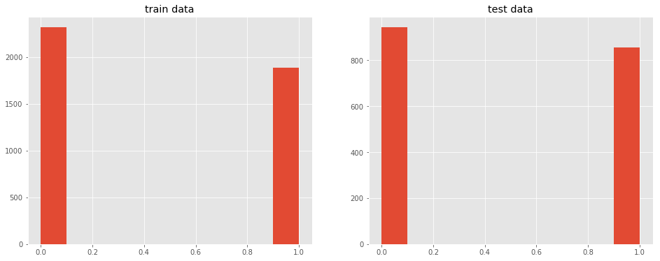

```python
plt.figure(figsize = (16, 6))

plt.subplot(1,2,1)
plt.hist(y_train)
plt.title('train data')

plt.subplot(1,2,2)
plt.hist(y_test)
plt.title('test data')
```

## тестируем выборку с нулями вместо пропусков

```python
estimator = LogisticRegression()
```

```python
optimizer = GridSearchCV(estimator, param_grid, cv=3)
```

```python
optimazer_zeros = optimizer.fit(X_train_zeros_cat, y_train)
```

```python
optimazer_zeros.best_estimator_
```

```
LogisticRegression(C=0.05, class_weight=None, dual=False, fit_intercept=True,
          intercept_scaling=1, max_iter=100, multi_class='ovr', n_jobs=1,
          penalty='l2', random_state=None, solver='liblinear', tol=0.0001,
          verbose=0, warm_start=False)
```

```python
[optimizer.grid_scores_[i][1] for i in range(7)]
```

```
[0.7807142857142857,
 0.795,
 0.7930952380952381,
 0.789047619047619,
 0.7842857142857143,
 0.7752380952380953,
 0.768095238095238]
```

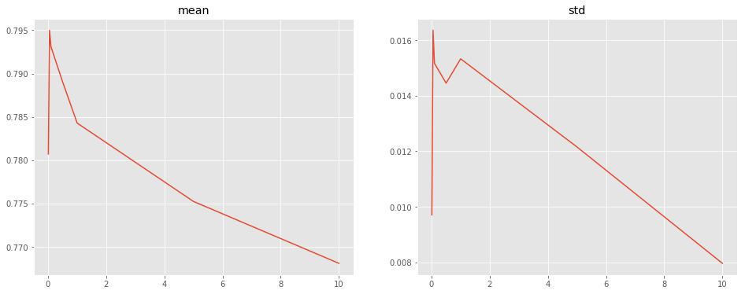

```python
# строим графики: значение метрики и ошибка. Визуализируем максимум.

# метрика
plt.figure(figsize = (16, 6))
plt.subplot(1,2,1)
plt.plot([optimizer.grid_scores_[i][0].values() for i in range(7)], [optimizer.grid_scores_[i][1] for i in range(7)])
plt.title('mean')

# ошибка
plt.subplot(1,2,2)
plt.plot([optimizer.grid_scores_[i][0].values() for i in range(7)], [optimizer.grid_scores_[i][2].std() for i in range(7)])
plt.title('std')
```

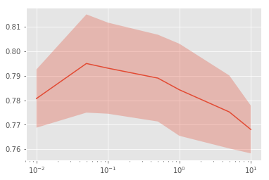

```python
plot_scores(optimizer)
```

## тестируем выборку со средними вместо пропусков

```python
# обучаем

optimizer_mean = optimizer.fit(X_train_mean_cat, y_train)
```

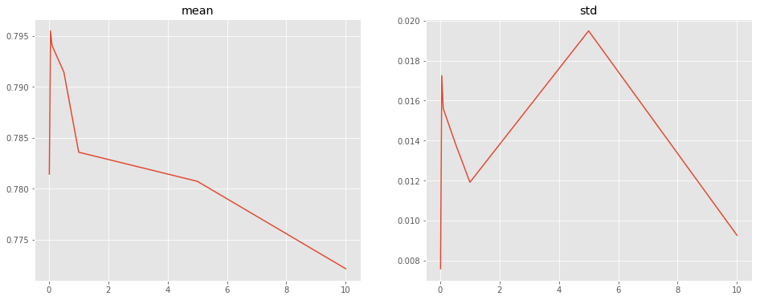

```python
# строим графики: значение метрики и ошибка. Визуализируем максимум.

# метрика
plt.figure(figsize = (16, 6))
plt.subplot(1,2,1)
plt.plot([optimizer_mean.grid_scores_[i][0].values() for i in range(7)], [optimizer_mean.grid_scores_[i][1] for i in range(7)])
plt.title('mean')

# ошибка
plt.subplot(1,2,2)
plt.plot([optimizer_mean.grid_scores_[i][0].values() for i in range(7)], [optimizer_mean.grid_scores_[i][2].std() for i in range(7)])
plt.title('std')
```

```python
def plot_scores_My(optimizer):
    plt.figure(figsize = (16, 6))
    plt.semilogx([optimizer.grid_scores_[i][0]['C'] for i in range(7)], [optimizer.grid_scores_[i][1] for i in range(7)])
    plt.fill_between([optimizer.grid_scores_[i][0]['C'] for i in range(7)],
                     [optimizer.grid_scores_[i][1] - optimizer.grid_scores_[i][2].std() for i in range(7)],
                     [optimizer.grid_scores_[i][1] + optimizer.grid_scores_[i][2].std() for i in range(7)], alpha=0.3)
    plt.title('mean +- std')
    return plt.show()
```

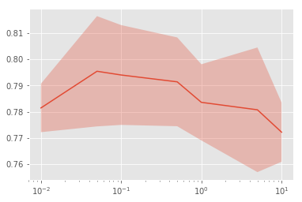

```python
plot_scores(optimizer)
```

Построим две метрики качества AUC ROC на тестовой выборке и сравним их между собой

1) с нулевыми пропусками

```python
AUC_ROC_0 = roc_auc_score(y_test, optimizer.predict_proba(X_test_zeros_cat)[:,1])
AUC_ROC_0
```

```
0.76341488162484483
```

2) со средними пропусками

```python
AUC_ROC_M = roc_auc_score(y_test, optimizer.predict_proba(X_test_mean_cat)[:,1])
AUC_ROC_M
```

```
0.88550097692139218
```

Вывод: дальше работаем со средними пропусками

### Масштабирование вещественных признаков

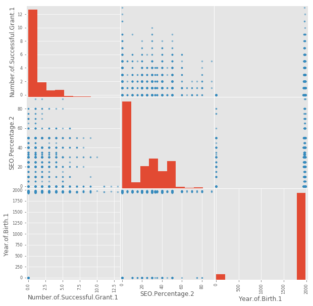

```python
# визуализация масштабов
from pandas.tools.plotting import scatter_matrix

data_numeric = pd.DataFrame(X_train_real_zeros, columns=numeric_cols)
list_cols = ['Number.of.Successful.Grant.1', 'SEO.Percentage.2', 'Year.of.Birth.1']
scatter_matrix(data_numeric[list_cols], alpha=0.5, figsize=(10, 10))
plt.show()
```

```python
from sklearn.preprocessing import StandardScaler
```

```python
scaler = StandardScaler()
```

```python
X_train_real_scaled = scaler.fit_transform(X_train_real_zeros)
```

```python
X_test_real_scaled = scaler.transform(X_test_real_zeros)
```

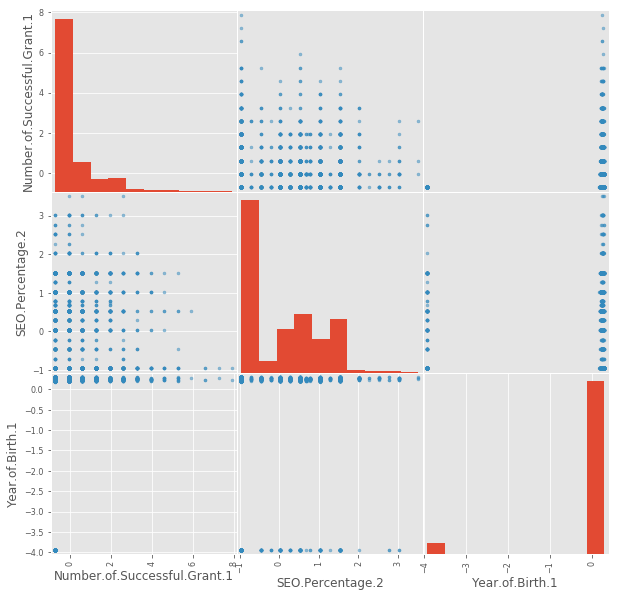

```python
# Сравнение признаковых пространств
data_numeric_scaled = pd.DataFrame(X_train_real_scaled, columns=numeric_cols)
list_cols = ['Number.of.Successful.Grant.1', 'SEO.Percentage.2', 'Year.of.Birth.1']
scatter_matrix(data_numeric_scaled[list_cols], alpha=0.5, figsize=(10, 10))
plt.show()
```

```python
# делаем обучающую выборку на новых признаках
X_train_zeros_cat_scaled = np.hstack([X_train_real_scaled, X_train_cat_oh])

# делаем тестовую выборку на новых признаках
X_test_zeros_cat_scaled = np.hstack([X_test_real_scaled, X_test_cat_oh])
```

```python
# новый оптимизатор гиперпараметров
optimizer_0_scaled = GridSearchCV(estimator, param_grid, cv=3)
```

```python
# обучаем
optimizer_0_scaled.fit(X_train_zeros_cat_scaled, y_train)
```

```
GridSearchCV(cv=3, error_score='raise',
       estimator=LogisticRegression(C=1.0, class_weight=None, dual=False, fit_intercept=True,
          intercept_scaling=1, max_iter=100, multi_class='ovr', n_jobs=1,
          penalty='l2', random_state=None, solver='liblinear', tol=0.0001,
          verbose=0, warm_start=False),
       fit_params={}, iid=True, n_jobs=1,
       param_grid={'C': [0.01, 0.05, 0.1, 0.5, 1, 5, 10]},
       pre_dispatch='2*n_jobs', refit=True, scoring=None, verbose=0)
```

```python
# оптимальный гиперпараметр
optimizer_0_scaled.best_params_
```

```
{'C': 0.05}
```

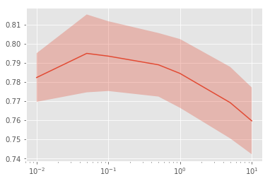

```python
plot_scores(optimizer_0_scaled)
```

```python
# контроль по метрике
AUC_0_scaled = roc_auc_score(y_test, optimizer_0_scaled.predict_proba(X_test_zeros_cat_scaled)[:,1])
AUC_0_scaled
```

```
0.88504437908262201
```